# SST and Chl-a Regional Summaries

September 09, 2021

##### Below are monthly time series of mean sea surface temperature (SST, $^\circ$C) and chlorophyll-a concentration (Chla, mg m<sup>-3</sup>) for regions and stations of interest, including Marine Protected Areas. Click on the tabs to view plots.

The SST is a 4km resolution product [available from NOAA](https://www.ncei.noaa.gov/products/avhrr-pathfinder-sst), covering late 1981 to present. The [Chla](https://oceancolor.gsfc.nasa.gov/atbd/chlor_a/) is a 4km product [available from the NASA Ocean Biology Processing Group](https://oceancolor.gsfc.nasa.gov/l3/) covering 2003 to present.

**Note that these plots are current to July, 2021.**

The time series are coloured by season: winter (January, February, March), spring (April, May, June), summer (July, August, September), and autumn (October, November, December).

**Click here to view map**

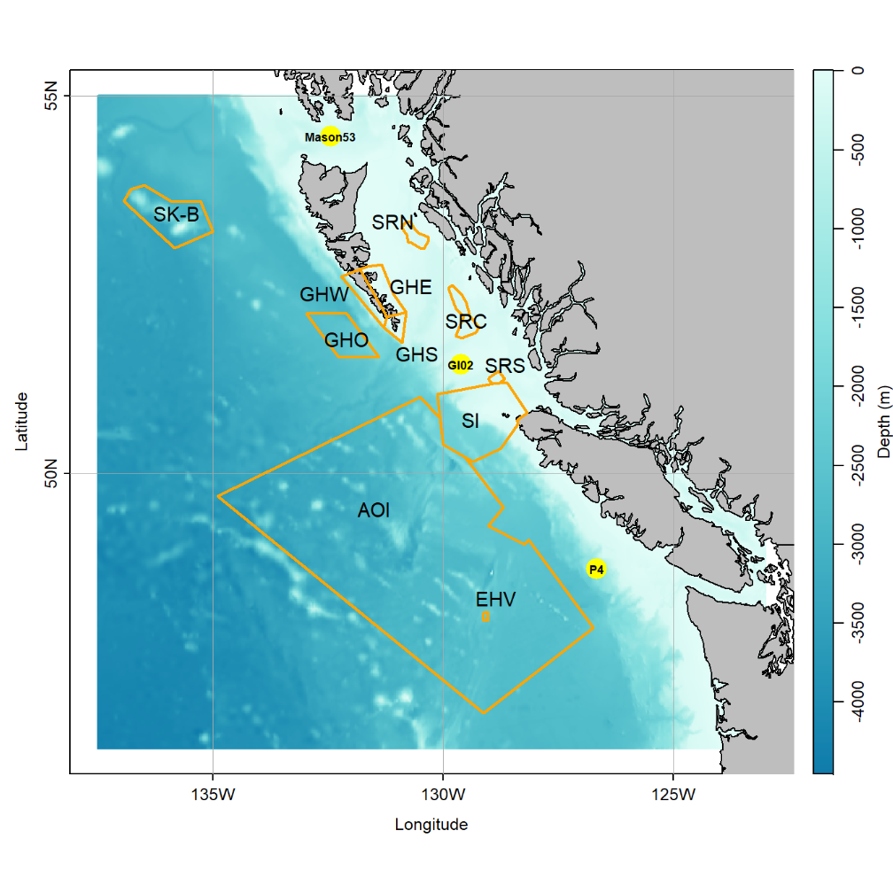

Oceanographic Regions *(orange boundary)*:

- **AOI:** [Offshore Pacific Area of Interest](https://www.dfo-mpo.gc.ca/oceans/aoi-si/offshore-hauturiere-eng.html)
- **EHV:** [Endeavour Hydrothermal Vents Marine Protected Area](https://www.dfo-mpo.gc.ca/oceans/mpa-zpm/endeavour/index-eng.html)
- **GH:** *East (GHE), Offshore (GHO), South (GHS), West (GHW)* [Gwaii Haanas National Marine Conservation Area Reserve](https://www.pc.gc.ca/en/pn-np/bc/gwaiihaanas)
- **SI:** [Scott Islands marine National Wildlife Area](https://www.canada.ca/en/environment-climate-change/services/national-wildlife-areas/locations/scott-islands-marine.html)
- **SK-B:** [SGaan Kinghlas-Bowie Seamount Marine Protected Area](https://www.dfo-mpo.gc.ca/oceans/mpa-zpm/bowie-eng.html)
- **SR:** *Central (SRC), North (SRN), South (SRS)* [Hecate Strait/Queen Charlotte Sound Glass Sponge Reefs Marine Protected Area](https://www.dfo-mpo.gc.ca/oceans/mpa-zpm/hecate-charlotte/index-eng.html)

*Selected* standard oceanographic stations *used for further calculations are shown as yellow points (stations GI02, Mason53, P4). The statistics used are from a 5x5 pixel box centered at the station coordinates.*

## Monthly Time Series

*The grey shaded area on the SST plots correspond to the Chla time series.*

### AOI

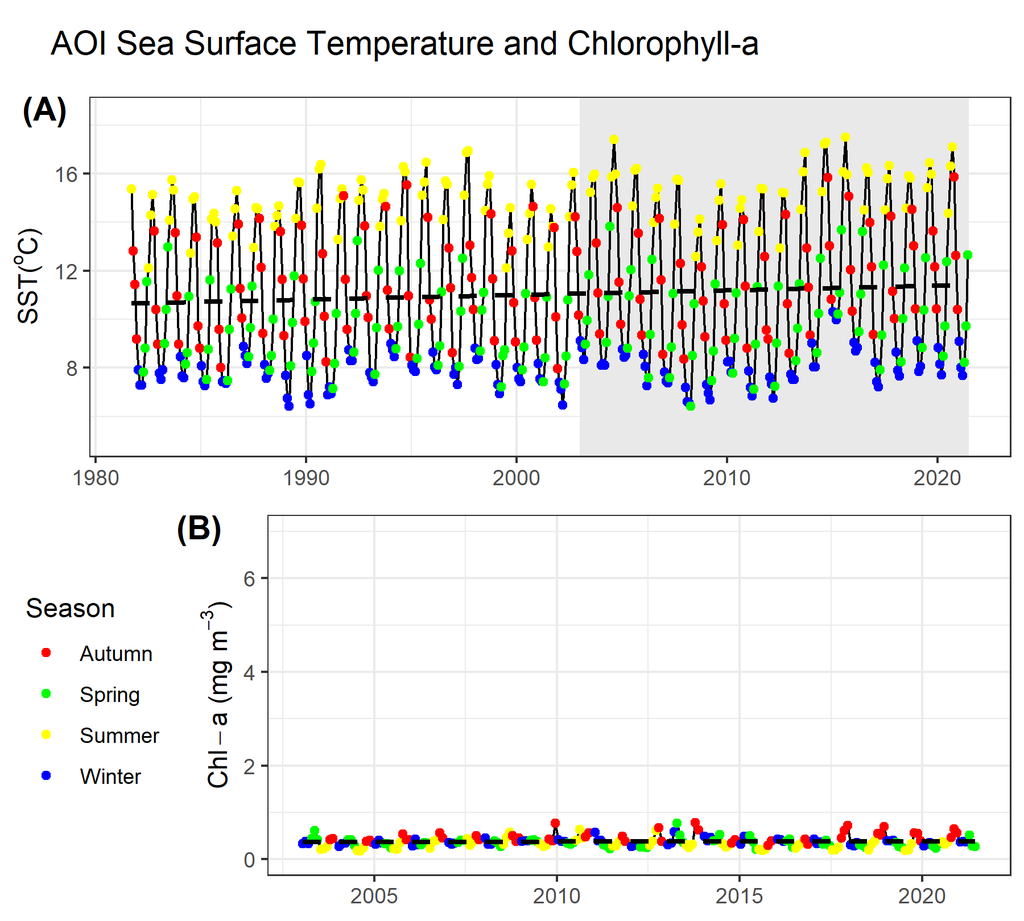

| Season | SST Slope (°C per decade) | Std error | P value |
| --- | --- | --- | --- |
| Winter | 0.24 | 0.06 | 0 |
| Spring | 0.20 | 0.14 | 0.13 |
| Summer | 0.36 | 0.08 | 0 |
| Fall | 0.27 | 0.17 | 0.11 |

| Season | Chl-a Slope (ug/L per decade) | Std error | P value |
| --- | --- | --- | --- |
| Winter | 0.019 | 0.02 | 0.21 |
| Spring | -0.036 | 0.02 | 0.12 |
| Summer | -0.001 | 0.03 | 0.96 |
| Fall | 0.033 | 0.03 | 0.27 |

### EHV

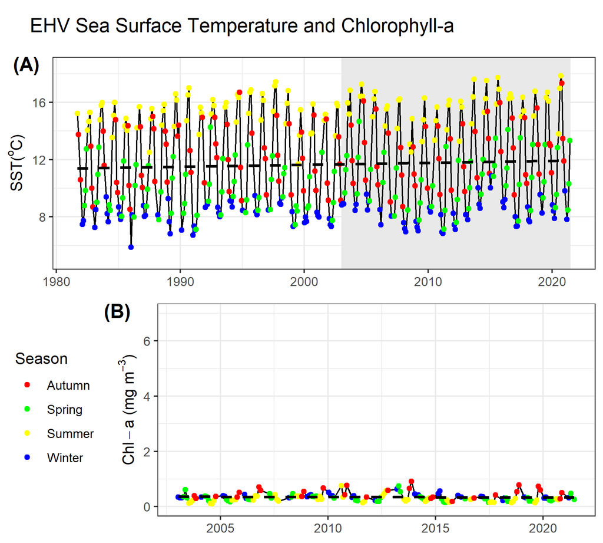

| Season | SST Slope (°C per decade) | Std error | P value |
| --- | --- | --- | --- |
| Winter | 0.18 | 0.07 | 0.01 |
| Spring | 0.32 | 0.14 | 0.03 |
| Summer | 0.30 | 0.09 | 0 |
| Fall | 0.34 | 0.17 | 0.06 |

| Season | Chl-a Slope (ug/L per decade) | Std error | P value |
| --- | --- | --- | --- |
| Winter | -0.013 | 0.02 | 0.59 |
| Spring | -0.042 | 0.03 | 0.14 |
| Summer | -0.020 | 0.04 | 0.56 |
| Fall | 0.005 | 0.06 | 0.93 |

### GH

#### Gwaii Haanas Marine Protected Area

##### East

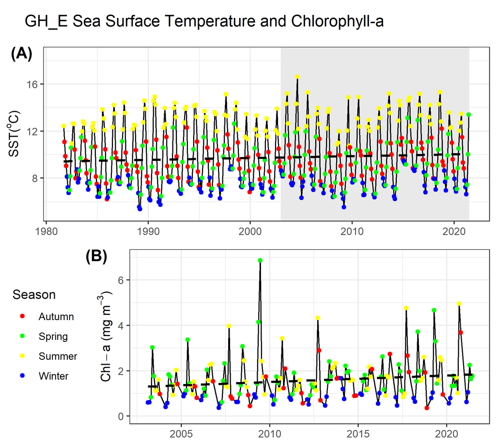

| Season | SST Slope (°C per decade) | Std error | P value |
| --- | --- | --- | --- |
| Winter | 0.19 | 0.07 | 0.01 |
| Spring | 0.10 | 0.14 | 0.46 |
| Summer | 0.05 | 0.10 | 0.57 |
| Fall | 0.16 | 0.11 | 0.14 |

| Season | Chl-a Slope (ug/L per decade) | Std error | P value |
| --- | --- | --- | --- |
| Winter | 0.063 | 0.05 | 0.24 |
| Spring | 0.199 | 0.24 | 0.41 |
| Summer | 0.494 | 0.25 | 0.06 |
| Fall | 0.779 | 0.24 | 0 |

##### South

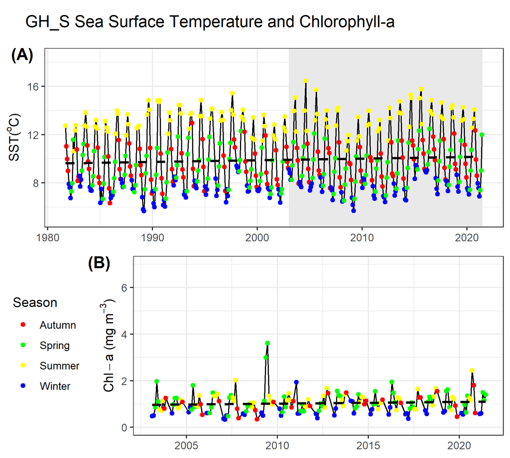

| Season | SST Slope (°C per decade) | Std error | P value |
| --- | --- | --- | --- |
| Winter | 0.16 | 0.06 | 0.01 |
| Spring | 0.01 | 0.12 | 0.92 |
| Summer | 0.11 | 0.08 | 0.18 |
| Fall | 0.14 | 0.11 | 0.23 |

| Season | Chl-a Slope (ug/L per decade) | Std error | P value |
| --- | --- | --- | --- |
| Winter | 0.003 | 0.05 | 0.94 |
| Spring | -0.006 | 0.12 | 0.96 |
| Summer | 0.152 | 0.09 | 0.09 |
| Fall | 0.240 | 0.09 | 0.01 |

##### West

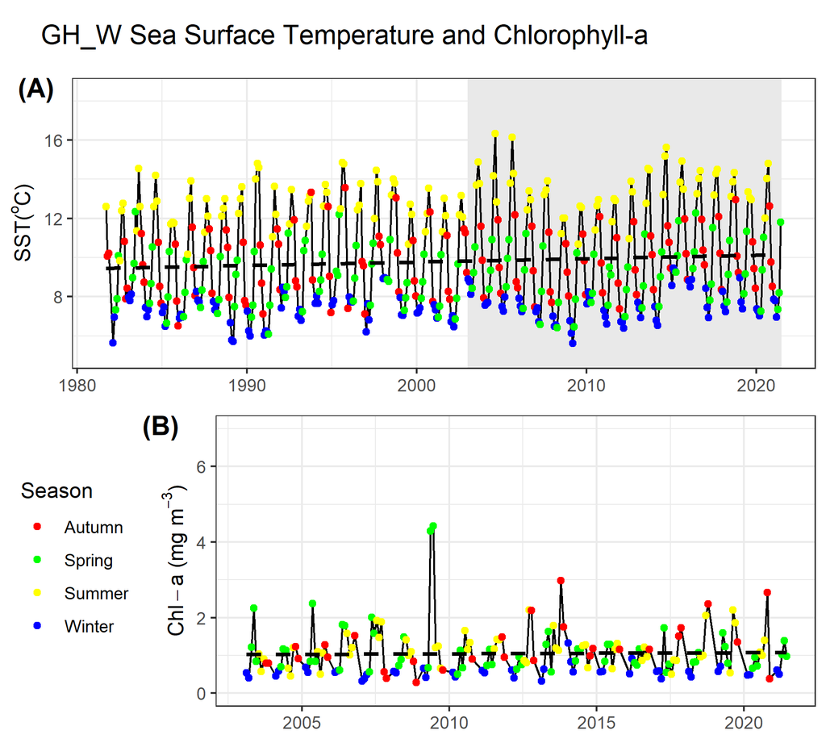

| Season | SST Slope (°C per decade) | Std error | P value |
| --- | --- | --- | --- |
| Winter | 0.12 | 0.07 | 0.07 |
| Spring | -0.08 | 0.11 | 0.43 |
| Summer | 0.28 | 0.09 | 0 |
| Fall | 0.12 | 0.13 | 0.33 |

| Season | Chl-a Slope (ug/L per decade) | Std error | P value |
| --- | --- | --- | --- |
| Winter | 0.034 | 0.04 | 0.37 |
| Spring | -0.243 | 0.16 | 0.14 |
| Summer | 0.186 | 0.12 | 0.12 |
| Fall | 0.482 | 0.20 | 0.02 |

##### Offshore

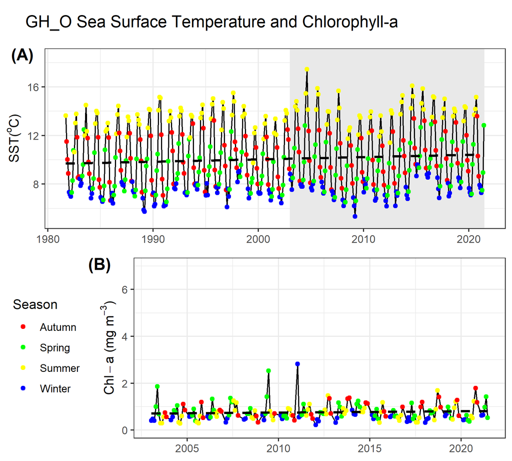

| Season | SST Slope (°C per decade) | Std error | P value |
| --- | --- | --- | --- |
| Winter | 0.22 | 0.06 | 0 |
| Spring | 0.15 | 0.13 | 0.24 |
| Summer | 0.30 | 0.09 | 0 |
| Fall | 0.19 | 0.13 | 0.17 |

| Season | Chl-a Slope (ug/L per decade) | Std error | P value |
| --- | --- | --- | --- |
| Winter | 0.021 | 0.05 | 0.7 |
| Spring | -0.160 | 0.09 | 0.07 |
| Summer | 0.273 | 0.09 | 0 |
| Fall | 0.287 | 0.09 | 0 |

### GI02

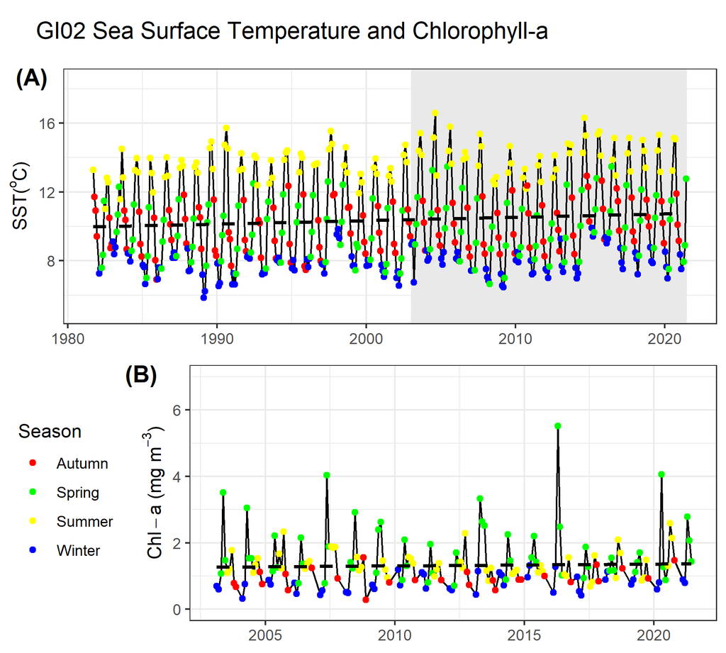

| Season | SST Slope (°C per decade) | Std error | P value |
| --- | --- | --- | --- |
| Winter | 0.18 | 0.07 | 0.01 |
| Spring | 0.15 | 0.14 | 0.28 |
| Summer | 0.30 | 0.08 | 0 |
| Fall | 0.24 | 0.11 | 0.03 |

| Season | Chl-a Slope (ug/L per decade) | Std error | P value |
| --- | --- | --- | --- |
| Winter | 0.085 | 0.06 | 0.18 |
| Spring | 0.020 | 0.19 | 0.92 |
| Summer | -0.087 | 0.11 | 0.43 |
| Fall | 0.121 | 0.08 | 0.13 |

### Mason-53

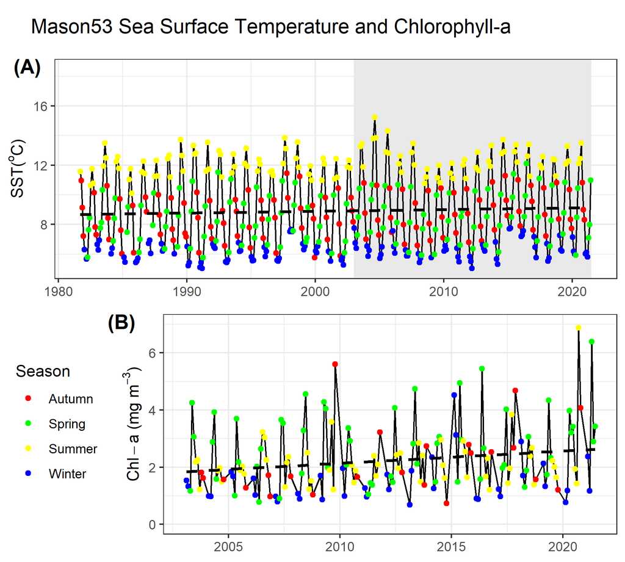

| Season | SST Slope (°C per decade) | Std error | P value |
| --- | --- | --- | --- |
| Winter | 0.13 | 0.06 | 0.03 |
| Spring | 0.08 | 0.13 | 0.53 |
| Summer | 0.21 | 0.08 | 0.01 |
| Fall | 0.24 | 0.12 | 0.05 |

| Season | Chl-a Slope (ug/L per decade) | Std error | P value |
| --- | --- | --- | --- |
| Winter | 0.255 | 0.17 | 0.15 |
| Spring | 0.294 | 0.31 | 0.34 |
| Summer | 0.322 | 0.20 | 0.12 |
| Fall | 0.499 | 0.39 | 0.21 |

### P4

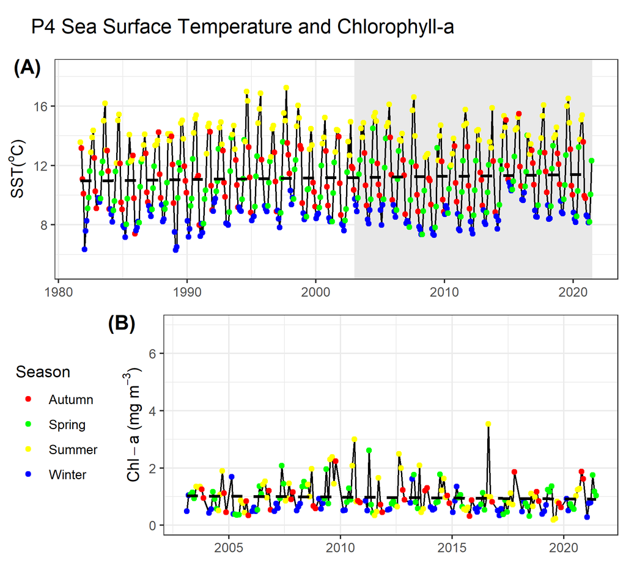

| Season | SST Slope (°C per decade) | Std error | P value |
| --- | --- | --- | --- |
| Winter | 0.22 | 0.07 | 0 |
| Spring | 0.09 | 0.13 | 0.47 |
| Summer | 0.14 | 0.09 | 0.15 |
| Fall | 0.10 | 0.14 | 0.45 |

| Season | Chl-a Slope (ug/L per decade) | Std error | P value |
| --- | --- | --- | --- |
| Winter | -0.081 | 0.08 | 0.34 |
| Spring | 0.016 | 0.11 | 0.89 |
| Summer | -0.133 | 0.20 | 0.5 |
| Fall | 0.136 | 0.15 | 0.38 |

### SI

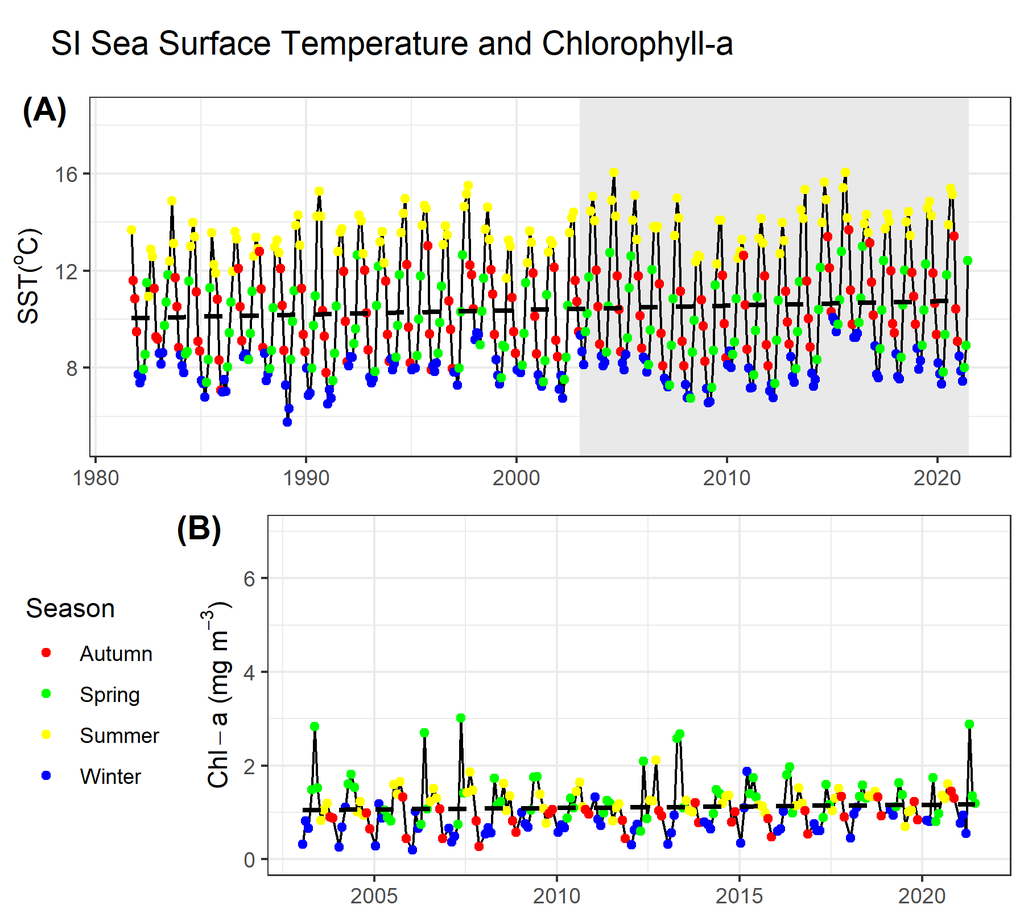

| Season | SST Slope (°C per decade) | Std error | P value |
| --- | --- | --- | --- |
| Winter | 0.20 | 0.06 | 0 |
| Spring | 0.13 | 0.13 | 0.3 |
| Summer | 0.32 | 0.07 | 0 |
| Fall | 0.21 | 0.11 | 0.07 |

| Season | Chl-a Slope (ug/L per decade) | Std error | P value |
| --- | --- | --- | --- |
| Winter | 0.054 | 0.06 | 0.39 |
| Spring | -0.002 | 0.14 | 0.99 |
| Summer | 0.003 | 0.07 | 0.96 |
| Fall | 0.185 | 0.06 | 0 |

### SK-B

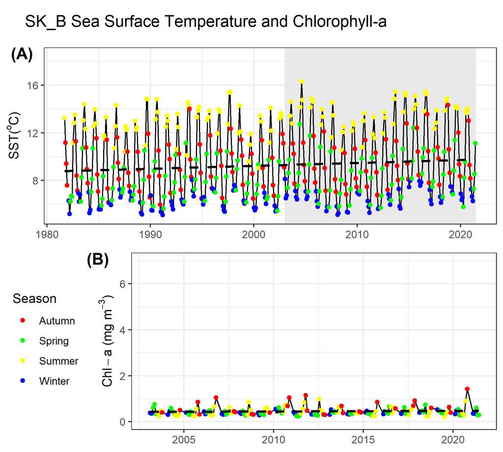

| Season | SST Slope (°C per decade) | Std error | P value |
| --- | --- | --- | --- |
| Winter | 0.24 | 0.06 | 0 |
| Spring | 0.12 | 0.14 | 0.38 |
| Summer | 0.29 | 0.10 | 0 |
| Fall | 0.20 | 0.15 | 0.18 |

| Season | Chl-a Slope (ug/L per decade) | Std error | P value |
| --- | --- | --- | --- |
| Winter | 0.043 | 0.02 | 0.05 |
| Spring | -0.047 | 0.03 | 0.12 |
| Summer | 0.050 | 0.05 | 0.29 |
| Fall | 0.140 | 0.09 | 0.13 |

### SR

#### Hecate Strait/Queen Charlotte Sound Glass Sponge Reefs Marine Protected Area

##### Central

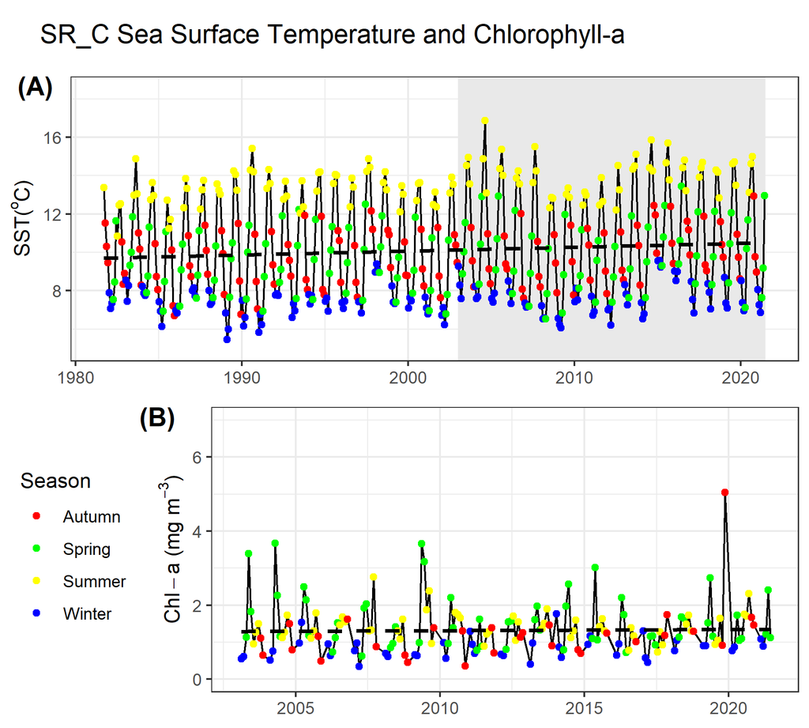

| Season | SST Slope (°C per decade) | Std error | P value |
| --- | --- | --- | --- |
| Winter | 0.18 | 0.07 | 0.01 |
| Spring | 0.09 | 0.14 | 0.52 |
| Summer | 0.32 | 0.08 | 0 |
| Fall | 0.32 | 0.11 | 0 |

| Season | Chl-a Slope (ug/L per decade) | Std error | P value |
| --- | --- | --- | --- |
| Winter | -0.011 | 0.07 | 0.88 |
| Spring | -0.277 | 0.18 | 0.13 |
| Summer | -0.026 | 0.10 | 0.8 |
| Fall | 0.118 | 0.15 | 0.44 |

##### North

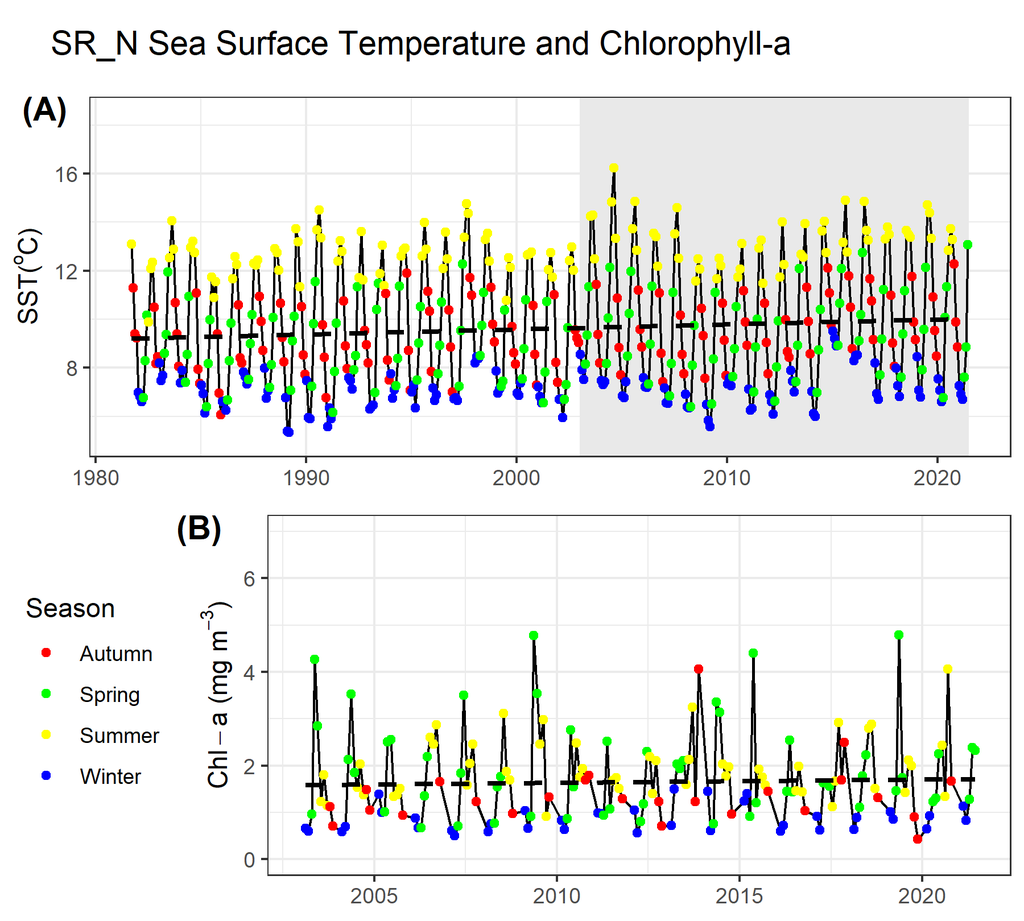

| Season | SST Slope (°C per decade) | Std error | P value |
| --- | --- | --- | --- |
| Winter | 0.15 | 0.06 | 0.02 |
| Spring | 0.17 | 0.13 | 0.21 |
| Summer | 0.30 | 0.08 | 0 |
| Fall | 0.31 | 0.11 | 0 |

| Season | Chl-a Slope (ug/L per decade) | Std error | P value |
| --- | --- | --- | --- |
| Winter | 0.077 | 0.07 | 0.3 |
| Spring | -0.269 | 0.27 | 0.31 |
| Summer | 0.300 | 0.16 | 0.06 |
| Fall | 0.083 | 0.14 | 0.56 |

##### South

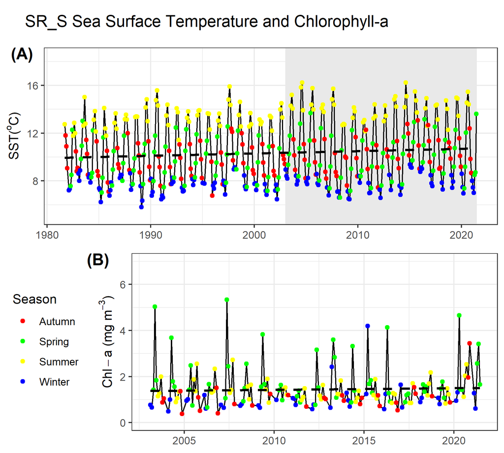

| Season | SST Slope (°C per decade) | Std error | P value |
| --- | --- | --- | --- |
| Winter | 0.12 | 0.06 | 0.04 |
| Spring | 0.17 | 0.15 | 0.26 |
| Summer | 0.32 | 0.08 | 0 |
| Fall | 0.21 | 0.11 | 0.05 |

| Season | Chl-a Slope (ug/L per decade) | Std error | P value |
| --- | --- | --- | --- |
| Winter | 0.133 | 0.18 | 0.47 |
| Spring | -0.108 | 0.26 | 0.68 |
| Summer | -0.081 | 0.12 | 0.5 |
| Fall | 0.138 | 0.12 | 0.26 |

## Climatology Plots

*The monthly climatological mean is indicated by a grey line, with shading at 25 and 75 percentiles, and dashed lines indicating upper and lower standard deviation from the mean. All regions are displayed on the same scale.*

*The progress of 2021 is shown as the black line with points coloured according to season.*

### Sea Surface Temperature

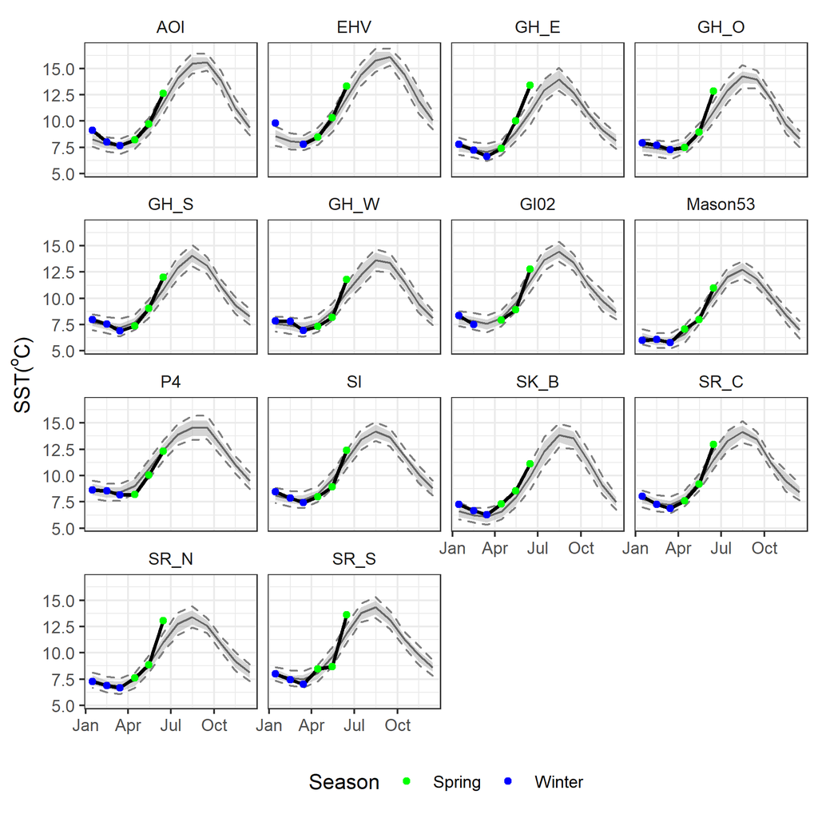

### Chlorophyll-a

#### Scaled y-axis

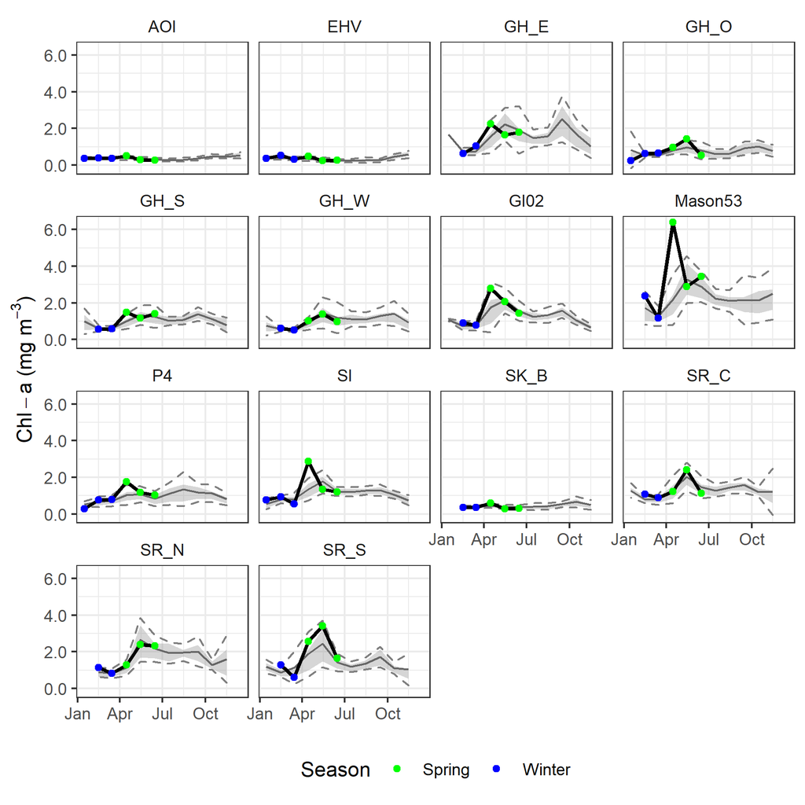

#### Variable y-axis

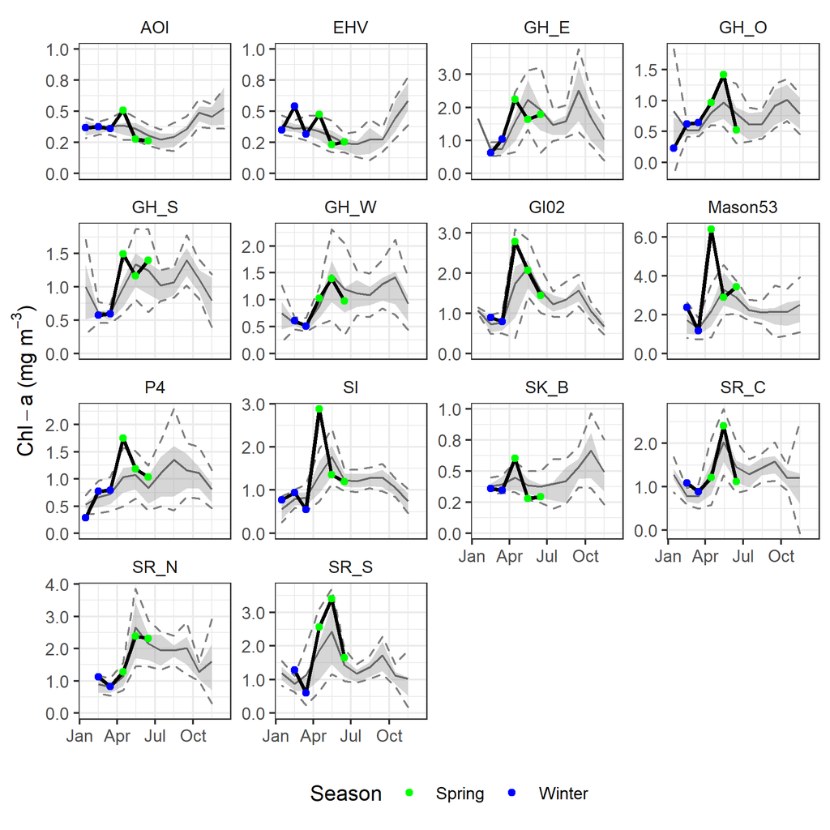

## Seasonal Trend Summary

*These tables summarize the monthly regional trends (also shown below the SST and Chl-a time series plots). Columns can be sorted by clicking on a heading and filtered using the search bar.*

### Sea Surface Temperature Trends

| Region | Season | SST Slope (°C per decade) | Std error | P value |
| --- | --- | --- | --- | --- |
| EHV | Winter | 0.18 | 0.07 | 0.01 |
| EHV | Spring | 0.32 | 0.14 | 0.03 |
| EHV | Summer | 0.30 | 0.09 | 0 |
| EHV | Fall | 0.34 | 0.17 | 0.06 |
| SI | Winter | 0.20 | 0.06 | 0 |
| SI | Spring | 0.13 | 0.13 | 0.3 |
| SI | Summer | 0.32 | 0.07 | 0 |
| SI | Fall | 0.21 | 0.11 | 0.07 |
| AOI | Winter | 0.24 | 0.06 | 0 |
| AOI | Spring | 0.20 | 0.14 | 0.13 |

[output cut: 46 more lines]

### Chlorophyll-a Trends

| Region | Season | Chl-a Slope (ug/L per decade) | Std error | P value |
| --- | --- | --- | --- | --- |
| EHV | Winter | -0.013 | 0.02 | 0.59 |
| EHV | Spring | -0.042 | 0.03 | 0.14 |
| EHV | Summer | -0.020 | 0.04 | 0.56 |
| EHV | Fall | 0.005 | 0.06 | 0.93 |
| SI | Winter | 0.054 | 0.06 | 0.39 |
| SI | Spring | -0.002 | 0.14 | 0.99 |
| SI | Summer | 0.003 | 0.07 | 0.96 |
| SI | Fall | 0.185 | 0.06 | 0 |
| AOI | Winter | 0.019 | 0.02 | 0.21 |
| AOI | Spring | -0.036 | 0.02 | 0.12 |

[output cut: 46 more lines]

SST data last updated: **2021-07-01**

Chla data last updated: **2021-07-01**

Original analysis by Melanie Hardy, Emmanuel Devred and Charles Hannah

[Hardy, M., Devred, E., and Hannah, C. 2021. Satellite observations of the Northeast Pacific Ocean. Can. Tech. Rep. Hydrogr. Ocean Sci. 335: vii + 46 p.](http://waves-vagues.dfo-mpo.gc.ca/Library/4092855x.pdf)

Assembly and modifications by Andrea Hilborn

*Contact: Andrea.Hilborn@dfo-mpo.gc.ca*